# Sample_Use_Case_Showcase

Subramanian K - Sample Use Case Walk through

This notebook is used to walk through **"Fraud Claims Detection"** use case with a sample open dataset.  
Based on the nature of the dataset attributes, several Machine Learning techniques can be applied.  
A glimpse of different options are shown below.

[figure not shown]

Each of the above family of ML approaches can be implemented using various algorithms.

In this walk through Supervised learning approach is considered. Primary factor that influenced this approach is nature of the dataset.  
The dataset considered contains labelled observations i.e already identified fraud/No-fraud claims records from the past.

*Importing the python libraries*

```python
import pandas as pd
from IPython.display import display
from matplotlib import pyplot as plt
import seaborn as sns
from sklearn.preprocessing import LabelEncoder
from sklearn.preprocessing import StandardScaler
from sklearn.model_selection import train_test_split
from sklearn.linear_model import LogisticRegression
from sklearn.metrics import classification_report
import xgboost as xgb
from imblearn.over_sampling import SMOTE
from imblearn.under_sampling import RandomUnderSampler
from sklearn.metrics import classification_report
from sklearn.metrics import accuracy_score
```

```python
#Pretty Print/display properties
PURPLE = '\033[95m'
CYAN = '\033[96m'
DARKCYAN = '\033[36m'
BLUE = '\033[94m'
GREEN = '\033[92m'
YELLOW = '\033[93m'
RED = '\033[91m'
BOLD = '\033[1m'
UNDERLINE = '\033[4m'
END = '\033[0m'
```

*Loading Dataset*

```python
dataSet = pd.read_csv('Fraud_Detection/Insurance_Claims.csv')
```

```python
dataSet.head()
```

|  | months_as_customer | age | policy_number | policy_bind_date | policy_state | policy_csl | policy_deductable | policy_annual_premium | umbrella_limit | insured_zip | ... | police_report_available | total_claim_amount | injury_claim | property_claim | vehicle_claim | auto_make | auto_model | auto_year | fraud_reported | _c39 |
| --- | --- | --- | --- | --- | --- | --- | --- | --- | --- | --- | --- | --- | --- | --- | --- | --- | --- | --- | --- | --- | --- |
| 0 | 328 | 48 | 521585 | 2014-10-17 | OH | 250/500 | 1000 | 1406.91 | 0 | 466132 | ... | YES | 71610 | 6510 | 13020 | 52080 | Saab | 92x | 2004 | Y | NaN |
| 1 | 228 | 42 | 342868 | 2006-06-27 | IN | 250/500 | 2000 | 1197.22 | 5000000 | 468176 | ... | ? | 5070 | 780 | 780 | 3510 | Mercedes | E400 | 2007 | Y | NaN |
| 2 | 134 | 29 | 687698 | 2000-09-06 | OH | 100/300 | 2000 | 1413.14 | 5000000 | 430632 | ... | NO | 34650 | 7700 | 3850 | 23100 | Dodge | RAM | 2007 | N | NaN |
| 3 | 256 | 41 | 227811 | 1990-05-25 | IL | 250/500 | 2000 | 1415.74 | 6000000 | 608117 | ... | NO | 63400 | 6340 | 6340 | 50720 | Chevrolet | Tahoe | 2014 | Y | NaN |
| 4 | 228 | 44 | 367455 | 2014-06-06 | IL | 500/1000 | 1000 | 1583.91 | 6000000 | 610706 | ... | NO | 6500 | 1300 | 650 | 4550 | Accura | RSX | 2009 | N | NaN |

5 rows × 40 columns

```python
print('Total Observations:',dataSet.shape[0])
```

```
Total Observations: 1000
```

*Performing Descriptive Analysis to find insights from data*

This is really important in real world because this gives business insights and proper data engineering tasks can be chosen based on the insights gained

```python
dataSet.info()
```

```
<class 'pandas.core.frame.DataFrame'>
RangeIndex: 1000 entries, 0 to 999
Data columns (total 40 columns):
 #   Column                       Non-Null Count  Dtype
---  ------                       --------------  -----
 0   months_as_customer           1000 non-null   int64
 1   age                          1000 non-null   int64
 2   policy_number                1000 non-null   int64
 3   policy_bind_date             1000 non-null   object
 4   policy_state                 1000 non-null   object
 5   policy_csl                   1000 non-null   object
 6   policy_deductable            1000 non-null   int64
 7   policy_annual_premium        1000 non-null   float64
 8   umbrella_limit               1000 non-null   int64
 9   insured_zip                  1000 non-null   int64
```

[output cut: 32 more lines]

**Observations:**

1. Total 40 Variables
2. Some variables have incorrect datatype
3. Dataset contains Categorical and Numerical variables
4. Few variables can be removed like '_c39'
5. Target Variable - 'fraud_reported'
6. Target variable takes only 2 possible values, So it falls under **Binary Classification** in Supervised Learning Approach

*Identifying Numerical and Categorical variables*

First step is always understand the dataset by identifying the variables. Based on the type of the variable, correct processing steps needs to be performed.

Different types of variables are shown below

[figure not shown]

```python
numerical_variables = dataSet._get_numeric_data().columns
categorical_variables = list(set(dataSet.columns) - set(numerical_variables))
```

```python
print(BOLD,UNDERLINE + 'Numerical Variables'+ END,*numerical_variables,sep='\n')
```

```
Numerical Variables
months_as_customer
age
policy_number
policy_deductable
policy_annual_premium
umbrella_limit
insured_zip
capital-gains
capital-loss
incident_hour_of_the_day
number_of_vehicles_involved
bodily_injuries
witnesses
total_claim_amount
injury_claim
property_claim
vehicle_claim
auto_year
_c39
```

```python
print(BOLD,UNDERLINE + 'Categorical Variables'+ END,*categorical_variables,sep='\n')
```

```
Categorical Variables
auto_make
property_damage
auto_model
policy_csl
incident_state
policy_state
insured_education_level
incident_date
police_report_available
insured_hobbies
incident_city
policy_bind_date
incident_type
insured_relationship
fraud_reported
collision_type
insured_occupation
incident_location
authorities_contacted
incident_severity
insured_sex
```

```python
binominal_variables = []
nominal_variables = []
for column in categorical_variables:
    if len(list(dataSet[column].unique())) <= 2:
        binominal_variables.append(column)
    else:
        nominal_variables.append(column)
```

```python
binominal_variables
```

```
['fraud_reported', 'insured_sex']
```

```python
nominal_variables
```

```
['auto_make',
 'property_damage',
 'auto_model',
 'policy_csl',
 'incident_state',
 'policy_state',
 'insured_education_level',
 'incident_date',
 'police_report_available',
 'insured_hobbies',
 'incident_city',
 'policy_bind_date',
 'incident_type',
 'insured_relationship',
 'collision_type',
 'insured_occupation',
 'incident_location',
 'authorities_contacted',
 'incident_severity']
```

*Identifying number of unique values for each Nominal Categorical Variables*

```python
for k, v in dataSet[nominal_variables].nunique().to_dict().items():
    print('{} = {}'.format(k,v))
```

```
auto_make = 14
property_damage = 3
auto_model = 39
policy_csl = 3
incident_state = 7
policy_state = 3
insured_education_level = 7
incident_date = 60
police_report_available = 3
insured_hobbies = 20
incident_city = 7
policy_bind_date = 951
incident_type = 4
insured_relationship = 6
collision_type = 4
insured_occupation = 14
incident_location = 1000
authorities_contacted = 5
incident_severity = 4
```

This specific dataset does not have signifance of ordinal variables where order matters.

*Identifying variable significance*

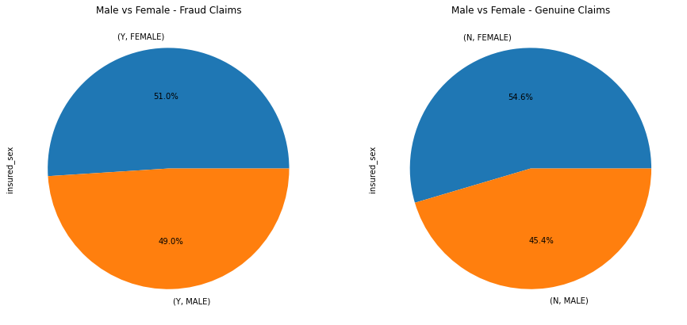

```python
fig, axes = plt.subplots(nrows=1, ncols=2)
dataSet[dataSet['fraud_reported']=='Y'].groupby(['fraud_reported']).insured_sex.value_counts().plot.pie(figsize=(15,10),autopct='%1.1f%%', ax=axes[0], title='Male vs Female - Fraud Claims')
dataSet[dataSet['fraud_reported']=='N'].groupby(['fraud_reported']).insured_sex.value_counts().plot.pie(figsize=(15,10),autopct='%1.1f%%', ax=axes[1], title='Male vs Female - Genuine Claims')
```

Sex doesn't seem to have significant effect

```python
dataSet['incident_severity'].unique()
```

```
array(['Major Damage', 'Minor Damage', 'Total Loss', 'Trivial Damage'],
      dtype=object)
```

```python
dataSet_IncidentSev = dataSet.groupby(['fraud_reported']).incident_severity.value_counts()
dataSet_IncidentSev
```

```
fraud_reported  incident_severity
N               Minor Damage         316
                Total Loss           244
                Major Damage         109
                Trivial Damage        84
Y               Major Damage         167
                Minor Damage          38
                Total Loss            36
                Trivial Damage         6
Name: incident_severity, dtype: int64
```

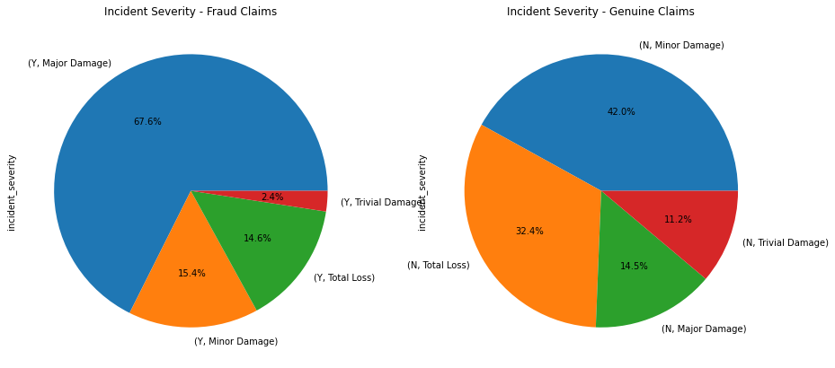

```python
fig, axes = plt.subplots(nrows=1, ncols=2)
dataSet[dataSet['fraud_reported']=='Y'].groupby(['fraud_reported']).incident_severity.value_counts().plot.pie(figsize=(15,10),autopct='%1.1f%%',  ax=axes[0], title='Incident Severity - Fraud Claims')
dataSet[dataSet['fraud_reported']=='N'].groupby(['fraud_reported']).incident_severity.value_counts().plot.pie(figsize=(15,10),autopct='%1.1f%%',  ax=axes[1], title='Incident Severity - Genuine Claims')
```

Most Fraud Claims belong to "Major Damage" incident severity type compared to other severity types.

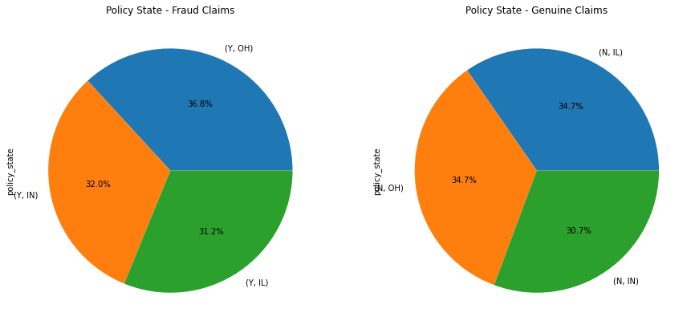

```python
fig, axes = plt.subplots(nrows=1, ncols=2)
dataSet[dataSet['fraud_reported']=='Y'].groupby(['fraud_reported']).policy_state.value_counts().plot.pie(figsize=(15,10),autopct='%1.1f%%',ax=axes[0], title='Policy State - Fraud Claims')
dataSet[dataSet['fraud_reported']=='N'].groupby(['fraud_reported']).policy_state.value_counts().plot.pie(figsize=(15,10),autopct='%1.1f%%',ax=axes[1], title='Policy State - Genuine Claims')
```

Policy State doesn't seem to have significant effect

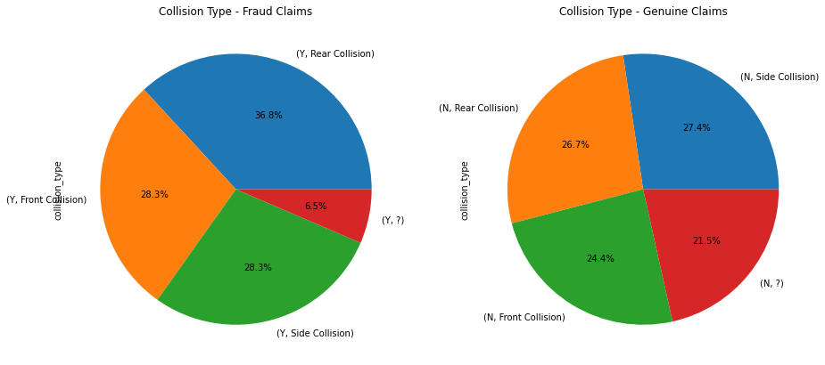

```python
fig, axes = plt.subplots(nrows=1, ncols=2)
dataSet[dataSet['fraud_reported']=='Y'].groupby(['fraud_reported']).collision_type.value_counts().plot.pie(figsize=(15,10),autopct='%1.1f%%', ax=axes[0], title='Collision Type - Fraud Claims')
dataSet[dataSet['fraud_reported']=='N'].groupby(['fraud_reported']).collision_type.value_counts().plot.pie(figsize=(15,10),autopct='%1.1f%%', ax=axes[1], title='Collision Type - Genuine Claims')
```

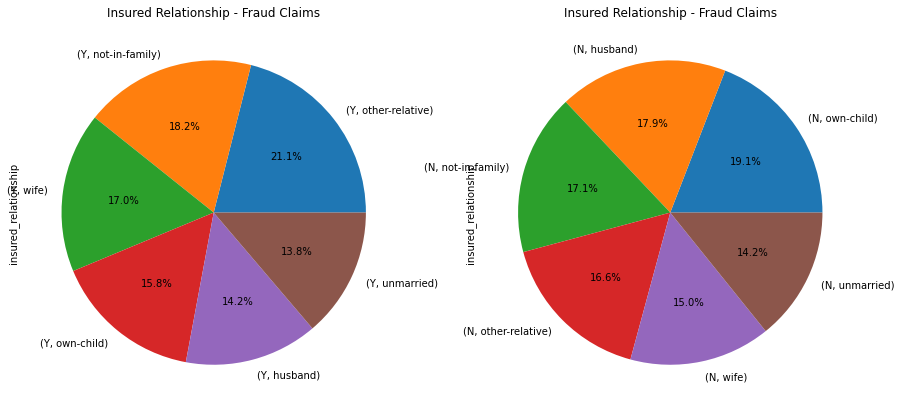

```python
fig, axes = plt.subplots(nrows=1, ncols=2)
dataSet[dataSet['fraud_reported']=='Y'].groupby(['fraud_reported']).insured_relationship.value_counts().plot.pie(figsize=(15,10),autopct='%1.1f%%', ax=axes[0], title='Insured Relationship - Fraud Claims' )
dataSet[dataSet['fraud_reported']=='N'].groupby(['fraud_reported']).insured_relationship.value_counts().plot.pie(figsize=(15,10),autopct='%1.1f%%', ax=axes[1], title='Insured Relationship - Fraud Claims' )
```

Insured Relationship doesn't seem to have significant effect

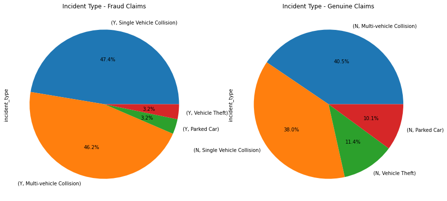

```python
fig, axes = plt.subplots(nrows=1, ncols=2)
dataSet[dataSet['fraud_reported']=='Y'].groupby(['fraud_reported']).incident_type.value_counts().plot.pie(figsize=(15,10),autopct='%1.1f%%', ax=axes[0], title='Incident Type - Fraud Claims')
dataSet[dataSet['fraud_reported']=='N'].groupby(['fraud_reported']).incident_type.value_counts().plot.pie(figsize=(15,10),autopct='%1.1f%%', ax=axes[1], title='Incident Type - Genuine Claims')
```

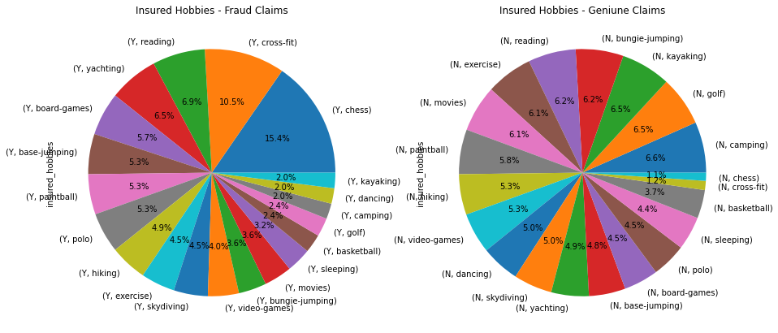

```python
fig, axes = plt.subplots(nrows=1, ncols=2)
dataSet[dataSet['fraud_reported']=='Y'].groupby(['fraud_reported']).insured_hobbies.value_counts().plot.pie(figsize=(15,10),autopct='%1.1f%%', ax=axes[0], title='Insured Hobbies - Fraud Claims')
dataSet[dataSet['fraud_reported']=='N'].groupby(['fraud_reported']).insured_hobbies.value_counts().plot.pie(figsize=(15,10),autopct='%1.1f%%', ax=axes[1], title='Insured Hobbies - Geniune Claims')
```

Interesting Fact is Insured Person with Hobbies as Chess and Cross-fit have involved more in Fraud Claims

```python
dataSet['insured_education_level'].unique()
```

```
array(['MD', 'PhD', 'Associate', 'Masters', 'High School', 'College',
       'JD'], dtype=object)
```

```python
dataSet.groupby(['fraud_reported']).insured_education_level.value_counts()
```

```
fraud_reported  insured_education_level
N               High School                124
                JD                         119
                Associate                  111
                Masters                    111
                MD                         106
                PhD                         92
                College                     90
Y               JD                          42
                MD                          38
                High School                 36
                Associate                   34
                PhD                         33
                College                     32
                Masters                     32
Name: insured_education_level, dtype: int64
```

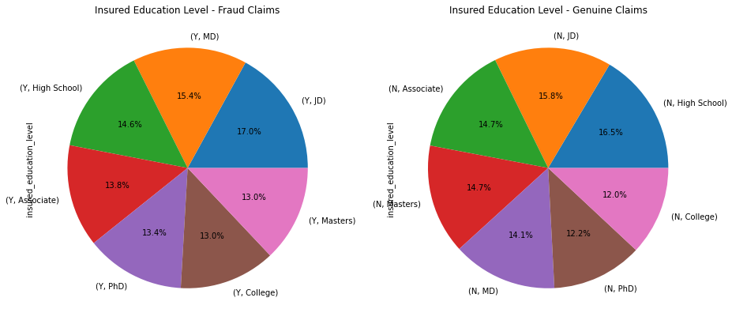

```python
fig, axes = plt.subplots(nrows=1, ncols=2)
dataSet[dataSet['fraud_reported']=='Y'].groupby(['fraud_reported']).insured_education_level.value_counts().plot.pie(figsize=(15,10),autopct='%1.1f%%', ax=axes[0], title='Insured Education Level - Fraud Claims')
dataSet[dataSet['fraud_reported']=='N'].groupby(['fraud_reported']).insured_education_level.value_counts().plot.pie(figsize=(15,10),autopct='%1.1f%%', ax=axes[1], title='Insured Education Level - Genuine Claims')
```

Education Level doesn't seem to have significant effect

```python
dataSet.groupby(['fraud_reported', 'incident_severity']).insured_education_level.value_counts()
```

```
fraud_reported  incident_severity  insured_education_level
N               Major Damage       Masters                    22
                                   High School                19
                                   Associate                  18
                                   MD                         18
                                   College                    13
                                   PhD                        10
                                   JD                          9
                Minor Damage       JD                         55
                                   High School                51
                                   Associate                  47
                                   Masters                    44
                                   PhD                        42
                                   College                    40
                                   MD                         37
                Total Loss         JD                         44
                                   MD                         42
                                   High School                38
                                   PhD                        33
                                   Associate                  31
                                   Masters                    30
                                   College                    26
                Trivial Damage     High School                16
                                   Associate                  15
                                   Masters                    15
                                   College                    11
                                   JD                         11
                                   MD                          9
                                   PhD                         7
Y               Major Damage       Associate                  28
                                   PhD                        27
                                   JD                         26
                                   College                    24
                                   MD                         23
                                   Masters                    21
                                   High School                18
                Minor Damage       High School                11
                                   JD                          7
                                   Masters                     7
                                   College                     5
                                   MD                          5
                                   PhD                         3
                Total Loss         MD                          9
                                   JD                          8
                                   High School                 6
                                   Associate                   5
                                   Masters                     4
                                   College                     3
                                   PhD                         1
                Trivial Damage     PhD                         2
                                   Associate                   1
                                   High School                 1
                                   JD                          1
                                   MD                          1
Name: insured_education_level, dtype: int64
```

```python
print(BOLD,UNDERLINE + 'Numerical Variables'+ END,*numerical_variables,sep='\n')
```

```
Numerical Variables
months_as_customer
age
policy_number
policy_deductable
policy_annual_premium
umbrella_limit
insured_zip
capital-gains
capital-loss
incident_hour_of_the_day
number_of_vehicles_involved
bodily_injuries
witnesses
total_claim_amount
injury_claim
property_claim
vehicle_claim
auto_year
_c39
```

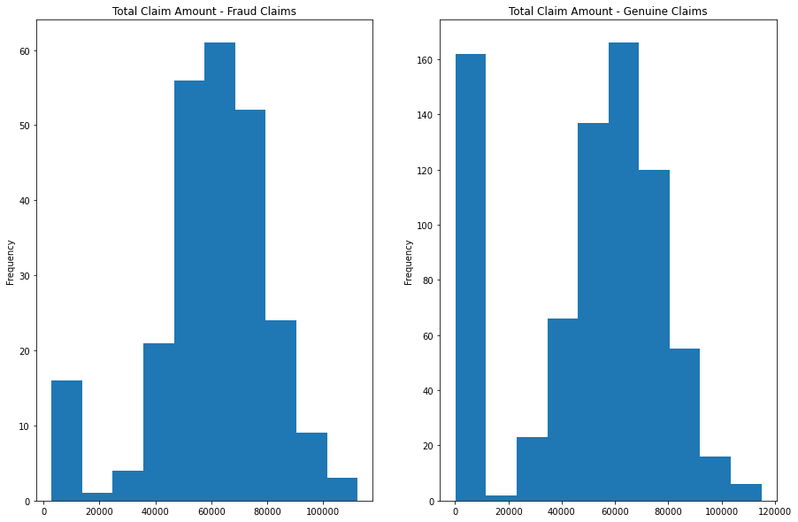

```python
fig, axes = plt.subplots(nrows=1, ncols=2)
dataSet[dataSet['fraud_reported']=='Y'].total_claim_amount.plot.hist(figsize=(15,10), ax=axes[0], title='Total Claim Amount - Fraud Claims')
dataSet[dataSet['fraud_reported']=='N'].total_claim_amount.plot.hist(figsize=(15,10), ax=axes[1], title='Total Claim Amount - Genuine Claims')
```

When Total Claim Amount is between 55k to 80k , We need to cautiously evaluate the claims based on historical trends

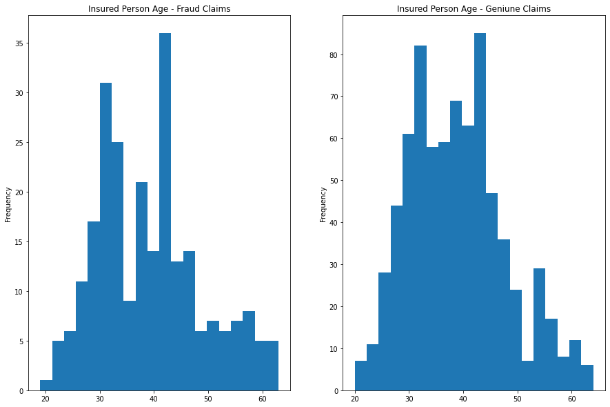

```python
fig, axes =plt.subplots(nrows=1, ncols=2)
dataSet[dataSet['fraud_reported']=='Y'].age.plot.hist(figsize=(15,10), bins=20, ax=axes[0], title='Insured Person Age - Fraud Claims')
dataSet[dataSet['fraud_reported']=='N'].age.plot.hist(figsize=(15,10), bins=20, ax=axes[1], title='Insured Person Age - Geniune Claims')
```

Age seem to have some effect on the Fraud Claims ratio

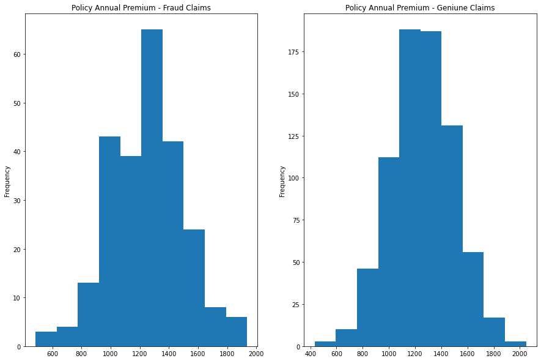

```python
fig, axes =plt.subplots(nrows=1, ncols=2)
dataSet[dataSet['fraud_reported']=='Y'].policy_annual_premium.plot.hist(figsize=(15,10), ax=axes[0], title='Policy Annual Premium - Fraud Claims')
dataSet[dataSet['fraud_reported']=='N'].policy_annual_premium.plot.hist(figsize=(15,10), ax=axes[1], title='Policy Annual Premium - Geniune Claims')
```

*Model Building*

Model Building starts with Data processing and cleaning. Unwanted columns are removed from the dataset to make the model simple

```python
dataSet.columns
```

```
Index(['months_as_customer', 'age', 'policy_number', 'policy_bind_date',
       'policy_state', 'policy_csl', 'policy_deductable',
       'policy_annual_premium', 'umbrella_limit', 'insured_zip', 'insured_sex',
       'insured_education_level', 'insured_occupation', 'insured_hobbies',
       'insured_relationship', 'capital-gains', 'capital-loss',
       'incident_date', 'incident_type', 'collision_type', 'incident_severity',
       'authorities_contacted', 'incident_state', 'incident_city',
       'incident_location', 'incident_hour_of_the_day',
       'number_of_vehicles_involved', 'property_damage', 'bodily_injuries',
       'witnesses', 'police_report_available', 'total_claim_amount',
       'injury_claim', 'property_claim', 'vehicle_claim', 'auto_make',
       'auto_model', 'auto_year', 'fraud_reported', '_c39'],
      dtype='object')
```

In this Analysis, Location and Text specific processing are not considered to keep it simple. In real life model, NLP based Text analytics and Geospatial location analysis can give more insights on the problem.

Few columns are dropped before model building, Based on the analysis so far, less significant or no significant columns are removed.

```python
dataSet.drop(['policy_number','policy_csl','policy_bind_date', 'insured_zip', 'incident_date','incident_location', 'incident_hour_of_the_day', 'auto_year', 'auto_make','auto_model','_c39'], axis=1, inplace=True)
```

Let me build a dataframe for categorical variables showing their possible values

```python
numerical_variables = dataSet._get_numeric_data().columns
categorical_variables = list(set(dataSet.columns) - set(numerical_variables))
```

```python
categorical_df = pd.DataFrame()
Numerical_df = pd.DataFrame()
```

```python
for variable in categorical_variables:
    nominal_string= dataSet[variable].unique()
    string = "\n".join(nominal_string)
    categorical_df[variable] = [string]
```

```python
# Setting display option for easy readability
display(categorical_df.style.set_properties(**{
    'text-align': 'left',
    'white-space': 'pre-wrap',
}))
```

|  | insured_occupation | authorities_contacted | incident_city | incident_severity | incident_type | insured_sex | insured_relationship | incident_state | insured_education_level | policy_state | police_report_available | property_damage | fraud_reported | collision_type | insured_hobbies |
| --- | --- | --- | --- | --- | --- | --- | --- | --- | --- | --- | --- | --- | --- | --- | --- |
| 0 | craft-repair machine-op-inspct sales armed-forces tech-support prof-specialty other-service priv-house-serv exec-managerial protective-serv transport-moving handlers-cleaners adm-clerical farming-fish… | Police None Fire Other Ambulance | Columbus Riverwood Arlington Springfield Hillsdale Northbend Northbrook | Major Damage Minor Damage Total Loss Trivial Damage | Single Vehicle Collision Vehicle Theft Multi-vehicle Collision Parked Car | MALE FEMALE | husband other-relative own-child unmarried wife not-in-family | SC VA NY OH WV NC PA | MD PhD Associate Masters High School College JD | OH IN IL | YES ? NO | YES ? NO | Y N | Side Collision ? Rear Collision Front Collision | sleeping reading board-games bungie-jumping base-jumping golf camping dancing skydiving movies hiking yachting paintball chess kayaking polo basketball video-games cross-fit exercise |

Measure of Central Tendency is critical to identify Data Skewness

```python
dataSet.agg(['mean', 'median']).transpose().astype(int)
```

|  | mean | median |
| --- | --- | --- |
| months_as_customer | 203 | 199 |
| age | 38 | 38 |
| policy_deductable | 1136 | 1000 |
| policy_annual_premium | 1256 | 1257 |
| umbrella_limit | 1101000 | 0 |
| capital-gains | 25126 | 0 |
| capital-loss | -26793 | -23250 |
| number_of_vehicles_involved | 1 | 1 |
| bodily_injuries | 0 | 1 |
| witnesses | 1 | 1 |
| total_claim_amount | 52761 | 58055 |
| injury_claim | 7433 | 6775 |
| property_claim | 7399 | 6750 |
| vehicle_claim | 37928 | 42100 |

In Statictical terms ,**Skewness** indicates where the data is concentrated towards

- Mean > Median
  - Positive Skew - Outliers are to the right side of the frequency distribution
- Mean = Median
  - Zero Skew
- Mean < Median
  - Negative Skew - Outliers are to the left of the frequency distribution

In real world applications of ML, Skewness needs to be handled. To keep it simple only inference is carried out for the dataset

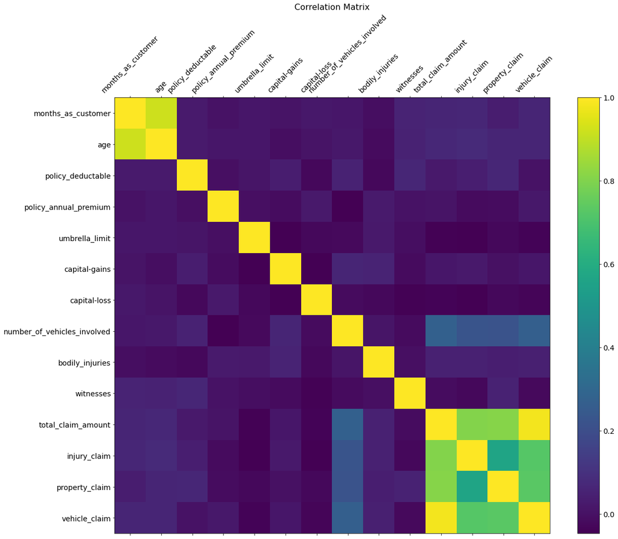

```python
f = plt.figure(figsize=(19, 15))
plt.matshow(dataSet.corr(), fignum=f.number)
plt.xticks(range(dataSet.select_dtypes(['number']).shape[1]), dataSet.select_dtypes(['number']).columns, fontsize=14, rotation=45)
plt.yticks(range(dataSet.select_dtypes(['number']).shape[1]), dataSet.select_dtypes(['number']).columns, fontsize=14)
cb = plt.colorbar()
cb.ax.tick_params(labelsize=14)
plt.title('Correlation Matrix', fontsize=16);
```

Correlation Heat Map is Build to identify highly correlated variables. This will help us to remove such variables from Model building process as these variables will not add any value to the ML Model

This shows Total Claim Amount, Injury Claim, Property Claim, Vehicle Claim are highly correlated.  
Since Total Claim Amount = Injury Claim + Property Claim + Vehicle Claim

```python
dataSet.drop(['injury_claim', 'property_claim', 'vehicle_claim'], axis=1, inplace=True)
```

```python
dataSet.columns
```

```
Index(['months_as_customer', 'age', 'policy_state', 'policy_deductable',
       'policy_annual_premium', 'umbrella_limit', 'insured_sex',
       'insured_education_level', 'insured_occupation', 'insured_hobbies',
       'insured_relationship', 'capital-gains', 'capital-loss',
       'incident_type', 'collision_type', 'incident_severity',
       'authorities_contacted', 'incident_state', 'incident_city',
       'number_of_vehicles_involved', 'property_damage', 'bodily_injuries',
       'witnesses', 'police_report_available', 'total_claim_amount',
       'fraud_reported'],
      dtype='object')
```

*Label Encoding and Dummy Variables*

This is necessary for any ML Model since Mathematical algorithms can work only with numbers.

```python
le = LabelEncoder()
for variable in binominal_variables:
    le.fit(dataSet[variable])
    dataSet[variable] = le.transform(dataSet[variable])
    print(le.classes_)
```

```
['N' 'Y']
['FEMALE' 'MALE']
```

Confirming no columns have null values

```python
dataSet.isnull().sum()
```

```
months_as_customer             0
age                            0
policy_state                   0
policy_deductable              0
policy_annual_premium          0
umbrella_limit                 0
insured_sex                    0
insured_education_level        0
insured_occupation             0
insured_hobbies                0
insured_relationship           0
capital-gains                  0
capital-loss                   0
incident_type                  0
collision_type                 0
incident_severity              0
authorities_contacted          0
incident_state                 0
incident_city                  0
number_of_vehicles_involved    0
property_damage                0
bodily_injuries                0
witnesses                      0
police_report_available        0
total_claim_amount             0
fraud_reported                 0
dtype: int64
```

Dataset shape before transformation

```python
dataSet.shape
```

```
(1000, 26)
```

```python
dataSet = pd.get_dummies(dataSet)
```

Dataset shape after transformation

```python
dataSet.shape
```

```
(1000, 100)
```

Identifying Positive and Negative class distribution

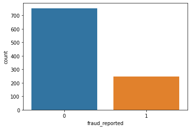

```python
sns.countplot(x='fraud_reported',data=dataSet)
```

```python
dataSet['fraud_reported'].value_counts()
```

```
0    753
1    247
Name: fraud_reported, dtype: int64
```

Sampling ratio is not balanced , This will have some effect on the model performance. This will be proved in the subsequent steps

```python
y=dataSet['fraud_reported']
X= dataSet.drop('fraud_reported',axis=1)
```

To avoid value based bias , dataset is normalized

```python
sc = StandardScaler()
X = sc.fit_transform(X)
```

In real world applications, Normal Train-test split is not a great option. Stratified split will be considered.

```python
X_train, X_test, y_train, y_test = train_test_split(X, y, test_size=0.2)
```

```python
y_train.value_counts()
```

```
0    599
1    201
Name: fraud_reported, dtype: int64
```

Starting with a simple **Logistic Regression**

```python
lr = LogisticRegression()

lr.fit(X_train, y_train)
preds = lr.predict(X_test)

score = lr.score(X_test, y_test)
print(score)
```

```
0.825
```

```python
print(classification_report(y_test, preds))
```

```
              precision    recall  f1-score   support

           0       0.91      0.86      0.88       154
           1       0.60      0.72      0.65        46

    accuracy                           0.82       200
   macro avg       0.76      0.79      0.77       200
weighted avg       0.84      0.82      0.83       200
```

More than accuracy of the model, for this use case F1-score is critical.  
Precision and Recall for Class "1" which is the actual Fraud claims is low even though the accuracy is 82.5%

Lets fix the sampling issue and rebuild the model to show the effect of low miniroty samples

```python
oversample = SMOTE(random_state=100)
```

```python
X_over, y_over = oversample.fit_sample(X_train, y_train)
```

```python
X_train_over, X_test_over, y_train_over, y_test_over = train_test_split(X_over, y_over, random_state = 1)
```

```python
lr.fit(X_train_over, y_train_over)
preds = lr.predict(X_test_over)
score = lr.score(X_test_over, y_test_over)
print(score)
print()
print(classification_report(y_test_over, preds))
```

```
0.91

              precision    recall  f1-score   support

           0       0.90      0.91      0.91       143
           1       0.92      0.91      0.91       157

    accuracy                           0.91       300
   macro avg       0.91      0.91      0.91       300
weighted avg       0.91      0.91      0.91       300
```

This has improved the f1-score for both postive and negative cases which is very much critical for Fraud detection. Business have to correctly classify both cases.

Lets Build an **Ensemble Model**

Only Boosting strategy is shown here, In actual applications research has to be done with Boosting, Bagging and Pasting or combination of those has to be tried

```python
D_train = xgb.DMatrix(X_train_over, label=y_train_over)
D_test = xgb.DMatrix(X_test_over, label=y_test_over)
```

```python
param = {
    'eta': 0.1,
    'max_depth': 3,

    'num_class': 2}

steps = 20
```

```python
xgmodel = xgb.train(param, D_train, steps)
```

```
[12:39:02] WARNING: ..\src\learner.cc:1061: Starting in XGBoost 1.3.0, the default evaluation metric used with the objective 'multi:softmax' was changed from 'merror' to 'mlogloss'. Explicitly set eval_metric if you'd like to restore the old behavior.
```

```python
xgpreds = xgmodel.predict(D_test)
```

```python
print(classification_report(y_test_over, xgpreds))
```

```
              precision    recall  f1-score   support

           0       0.94      0.93      0.93       143
           1       0.94      0.94      0.94       157

    accuracy                           0.94       300
   macro avg       0.94      0.94      0.94       300
weighted avg       0.94      0.94      0.94       300
```

As expected Ensemble Model is performing better with **94%** F1-Score for Fraud Claims.

**Conclusion:**

```
1. Based on the dataset, an ML Family has to be choosed
2. Perform Model Building using different algorithms for better performance
3. For improved performance Ensemble apporaches can be employed
4. For Big Data kind of distributed environment, Prefer Spark based learning
5. Always perform initial data analysis, so Business insights from data can be verified with the stakeholders before spending time and money on Model Building
```